# Exercises STAT340 - GLM 2

You will need these libraries and files for these exercises:

```r
library(BIAS.data)
library(nnet)
load("taxonomy.Rdata")
data(species)
source("summaryMultinom.R") # Can be downloaded from the CANVAS module.
```

# 1 Ex-1: Count data

Consider the plant species count data `species.Rdata`.

1. Redo the analysis from the lesson using the `Biomass` and `pH` variables as predictors for species counts in a Poisson regression model. Note that the default parametrization for GLM is “reference level” which here means that the effect of PH=High is set to zero. Find separate expressions for the estimated linear predictors $\widehat{\eta}_j$ for each $j=$ `pH`-levels = “`low`”,“`medium`”,“`high`”. Also find the estimated expected count for `Biomass = 2` and `pH = high`.

**Solution**

First we fit the model:

```
##
## Call:
## glm(formula = Species ~ Biomass + pH, family = poisson(log),
##     data = species)
##
## Coefficients:
##             Estimate Std. Error z value Pr(>|z|)
## (Intercept)  3.84894    0.05281  72.885  < 2e-16 ***
## Biomass     -0.12756    0.01014 -12.579  < 2e-16 ***
## pHlow       -1.13639    0.06720 -16.910  < 2e-16 ***
## pHmid       -0.44516    0.05486  -8.114 4.88e-16 ***
## ---
## Signif. codes:  0 '***' 0.001 '**' 0.01 '*' 0.05 '.' 0.1 ' ' 1
##
## (Dispersion parameter for poisson family taken to be 1)
##
##     Null deviance: 452.346  on 89  degrees of freedom
## Residual deviance:  99.242  on 86  degrees of freedom
## AIC: 526.43
##
## Number of Fisher Scoring iterations: 4
```

Then the estimated linear predictors are:

$$\eta_\text{low} = (3.85 - 1.14) -
0.128\cdot \text{Biomass} = 2.71 - 0.128\cdot \text{Biomass}$$
$$\eta_\text{medium} = (3.85 - 0.45) -
0.128\cdot \text{Biomass} = 3.4 - 0.128\cdot \text{Biomass}$$
$$\eta_\text{high} = 3.85 - 0.128\cdot
\text{Biomass}$$
For `Biomass = 2` and `pH = high` the estimated expected count is:

$$\widehat{\lambda} = \exp(3.85 -
0.128\cdot 2) = 36.4$$

```
##       link    se.link response se.response
## 1 3.593825 0.04007109 36.37293    1.457503
```

If we compute the estimated expected counts (predicted values) for different values of Biomass for each of the three pH-levels in a similar way, we may obtain fitted curves as shown below. Verify from the plot that Biomass=2 for pH=‘high’ gives approximately a fitted value of 36.4.

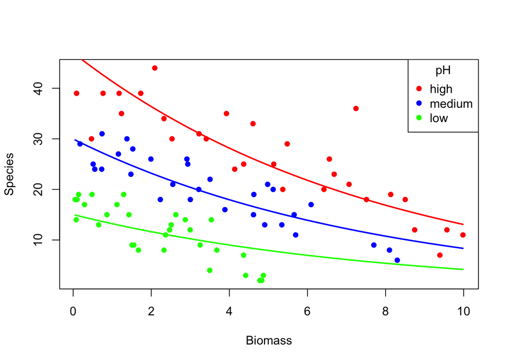

2. Fit the same model as in a. using the quasipoisson approach. Is there any evidence of overdisperion?

**Solution**

```
##
## Call:
## glm(formula = Species ~ Biomass + pH, family = quasipoisson,
##     data = species)
##
## Coefficients:
##             Estimate Std. Error t value Pr(>|t|)
## (Intercept)  3.84894    0.05556  69.281   <2e-16 ***
## Biomass     -0.12756    0.01067 -11.957   <2e-16 ***
## pHlow       -1.13639    0.07070 -16.074   <2e-16 ***
## pHmid       -0.44516    0.05771  -7.713    2e-11 ***
## ---
## Signif. codes:  0 '***' 0.001 '**' 0.01 '*' 0.05 '.' 0.1 ' ' 1
##
## (Dispersion parameter for quasipoisson family taken to be 1.106751)
##
##     Null deviance: 452.346  on 89  degrees of freedom
## Residual deviance:  99.242  on 86  degrees of freedom
## AIC: NA
##
## Number of Fisher Scoring iterations: 4
```

The dispersion parameter is only marginally larger than 1. We conclude that over-disperion is not a big problem here.

3. Extend the model from a. by including an interaction between Biomass and pH. Test the significance of the interaction. Is there a significant difference between pH=“high” and pH=“medium” with regard to the effect of Biomass to the species count?

**Solution**

First we fit the model with interaction term and get these results:

```
##
## Call:
## glm(formula = Species ~ Biomass * pH, family = poisson(log),
##     data = species)
##
## Coefficients:
##               Estimate Std. Error z value Pr(>|z|)
## (Intercept)    3.76812    0.06153  61.240  < 2e-16 ***
## Biomass       -0.10713    0.01249  -8.577  < 2e-16 ***
## pHlow         -0.81557    0.10284  -7.931 2.18e-15 ***
## pHmid         -0.33146    0.09217  -3.596 0.000323 ***
## Biomass:pHlow -0.15503    0.04003  -3.873 0.000108 ***
## Biomass:pHmid -0.03189    0.02308  -1.382 0.166954
## ---
## Signif. codes:  0 '***' 0.001 '**' 0.01 '*' 0.05 '.' 0.1 ' ' 1
##
## (Dispersion parameter for poisson family taken to be 1)
##
##     Null deviance: 452.346  on 89  degrees of freedom
## Residual deviance:  83.201  on 84  degrees of freedom
## AIC: 514.39
##
## Number of Fisher Scoring iterations: 4
```

The approximate normal tests (the z-test/Wald tests) only give significance tests for whether individual parameters are equal to zero. For instance, the Wald test gave a p-value of 0.167 for the term `Biomass:pH(mid)` which really is the contrast between interactions `Biomass:pH(high)`and `Biomass:pH(mid)` since `pH(high)` is the reference level in this model. The relatively large p-value says that there is no evidence that Biomass has different effect on counts for these two pH-levels. On the other hand there appears to be a significant difference in the effect of Biomass between `pH(high)` and `pH(low)` with a p-value of 0.000108. In order to evaluate the *overall* significance of the interaction term (Biomass:pH) we can look at the deviance tests in the Analysis of Deviance Table:

```
## Analysis of Deviance Table
##
## Model: poisson, link: log
##
## Response: Species
##
## Terms added sequentially (first to last)
##
##
##            Df Deviance Resid. Df Resid. Dev  Pr(>Chi)
## NULL                          89     452.35
## Biomass     1   44.673        88     407.67 2.328e-11 ***
## pH          2  308.431        86      99.24 < 2.2e-16 ***
## Biomass:pH  2   16.040        84      83.20 0.0003288 ***
## ---
## Signif. codes:  0 '***' 0.001 '**' 0.01 '*' 0.05 '.' 0.1 ' ' 1
```

```
## 'log Lik.' -251.1957 (df=6)
```

Here we can read out that adding the interaction term to a model already containing Biomass and pH will reduce the deviance with 16.040 and the qhi-square test on this deviance with 2 degrees of freedom returns a p-value of 0.00033, hence a highly significant interaction.

We could also get the same result by comparing the interaction model (as a full model) with the model from exercises a) (as a reduced model) and then use Models > Hypothesis test > Compare two models

```
## Analysis of Deviance Table
##
## Model 1: Species ~ Biomass + pH
## Model 2: Species ~ Biomass * pH
##   Resid. Df Resid. Dev Df Deviance  Pr(>Chi)
## 1        86     99.242
## 2        84     83.201  2    16.04 0.0003288 ***
## ---
## Signif. codes:  0 '***' 0.001 '**' 0.01 '*' 0.05 '.' 0.1 ' ' 1
```

The interaction term is again highly significant with a p-value of 0.00033.

A corresponding plot as made in a) including interaction effect yields:

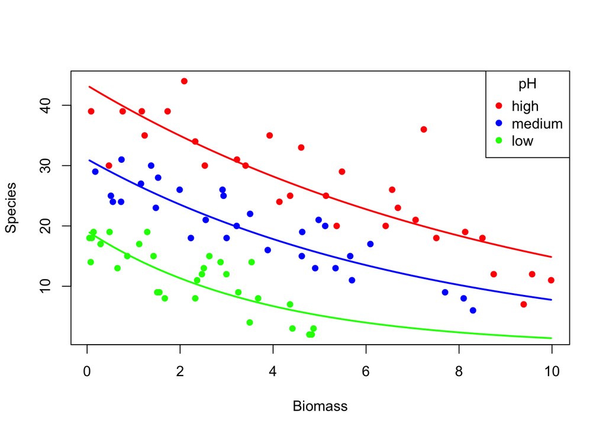

Note now how the curves differ from those found in a). That change is the interaction effect.

# 2 Ex-2: Multinomial data

We return to the taxonomy data used in the lecture on cluster analysis. In the file `taxonomy.Rdata` you find seven variables measured on plants from four different taxa.

1. Fit a multinomial regression with `Taxon` as the multinomial categorical response variable and `Sepal` as predictor. Is the effect of `Sepal` on the probabilities of the various taxons sifnificant at a 5% test level? Download the “summaryMultinom.R” file from the CANVAS-module and source it in R. This file contains code to summarize the multinomial regression model through the summaryMultinom() function which can be applied to the fitted multinomial model. The function will give you the estimated regression coefficients, the standard errors, the z-values and the p-values for each of the regression coefficients.

**Solution**

```r
library(nnet, pos=22)
source("summaryMultinom.R")
mod1.multi <- multinom(Taxon ~ Sepal, data=taxonomy, trace=FALSE)
summaryMultinom(mod1.multi)
```

```
## Call:
## multinom(formula = Taxon ~ Sepal, data = taxonomy, trace = FALSE)
##
## II                  Coef   SE Coef          Z         P
##   (Intercept)  1.4944725 2.3138262  0.6458880 0.5183519
##   Sepal       -0.5945128 0.9144496 -0.6501318 0.5156071
##
## III                Coef   SE Coef         Z         P
##   (Intercept)  2.873240 2.3177894  1.239647 0.2151061
##   Sepal       -1.152826 0.9242414 -1.247321 0.2122799
##
## IV                 Coef  SE Coef          Z         P
##   (Intercept) -48.02282 84.89788 -0.5656540 0.5716290
##   Sepal        13.71905 24.21469  0.5665589 0.5710139
##
## Analysis of Deviance Table (Type II tests)
##
## Response: Taxon
##       LR Chisq Df Pr(>Chisq)
## Sepal   136.53  3  < 2.2e-16 ***
## ---
## Signif. codes:  0 '***' 0.001 '**' 0.01 '*' 0.05 '.' 0.1 ' ' 1
##
## Residual Deviance: 196.1845
## AIC: 208.1845
## 'log Lik.' -98.09224 (df=6)
```

The Deviance test gives a p-value much smaller than 0.05, and `Sepal` is found to influence the probability of taxons significantly.

2. What are the estimated linear predictors $\widehat{\eta}_j$ for each of the four taxa, $j=1,2,3,4$?

**Solution**

First we extract the estimated regression coefficients. Remember that for the reference level taxon (`taxon=1`) the regression coefficients are assumed equal to zero. We may sum up the estimated coefficients like this:

```r
summod1.multi <- summary(mod1.multi)
co <- summod1.multi$coefficients
co <- rbind(c(0,0),co)
rownames(co)[1] <- "I"
co
```

```
##     (Intercept)      Sepal
## I      0.000000  0.0000000
## II     1.494472 -0.5945128
## III    2.873240 -1.1528256
## IV   -48.022819 13.7190515
```

This gives the following linear predictors:
$$\widehat{\eta}_1 = 0 + 0\cdot \text{Sepal} =
0$$
$$\widehat{\eta}_2 = 1.49 -
0.593\cdot \text{Sepal}$$
$$\widehat{\eta}_3 = 2.86 - 1.15\cdot
\text{Sepal}$$
$$\widehat{\eta}_4 =
-48.0 + 13.7\cdot \text{Sepal}$$

3. What is the most probable taxon according to this model for a plant with `Sepal=3`? (Hint: First insert `Sepal=3` in the linear predictors you just found to obtain the actual value of this. Then use the expression for the probability of a outcome $j$:

$$\widehat{p}_j=\frac{e^{\widehat{\eta}_j}}{\sum_k
e^{\widehat{\eta}_k}}= \frac{e^{\widehat{\eta}_j}}{
e^{\widehat{\eta}_1}+e^{\widehat{\eta}_2}+e^{\widehat{\eta}_3}+e^{\widehat{\eta}_4}}$$

**Solution**

This should give the estimated probabilities:

```
##            I           II          III           IV
## 0.4334671677 0.3246508189 0.2414299119 0.0004521015
```

We see that taxon I is the most probable with a probability equal to `0.43`.

Extra: The following figure shows the probabilities of each taxon for various values of `Sepal`. Remember that these probabilities are the posterior probability estimates for the class in a classification terminology. We classify to the most probable class given the observed predictor values.

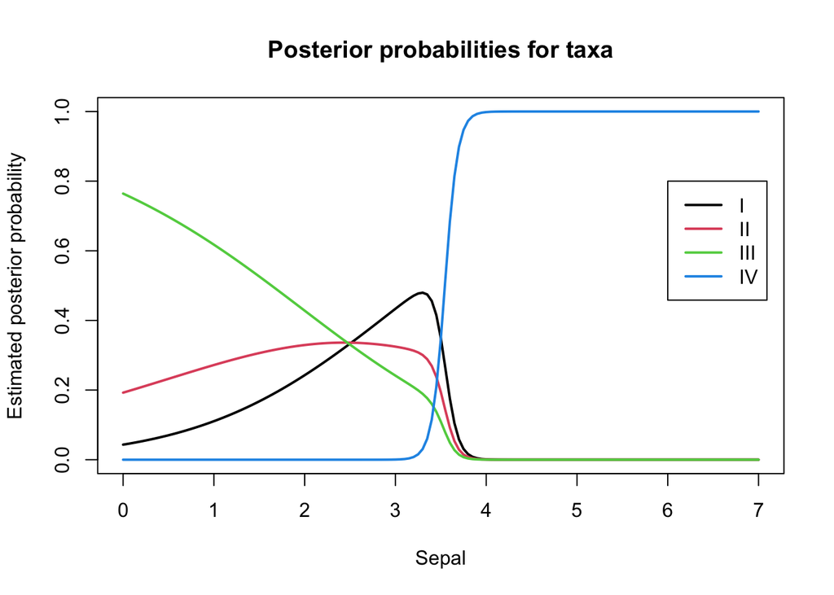

We observe that taxon III is the most probable for `Sepal<2.5`, taxon I for `2.5 < Sepal < 3.5` and taxon IV for `Sepal >= 3.5`. Taxon 2 is the most probable taxon only for `Sepal` $\approx$ `2.5`.

4. Create a Boxplot of `Sepal` from the Graph menu and choose to plot by groups identified by the taxon levels. Can you see why Sepal appears to be informative with regard to taxon?

**Solution**

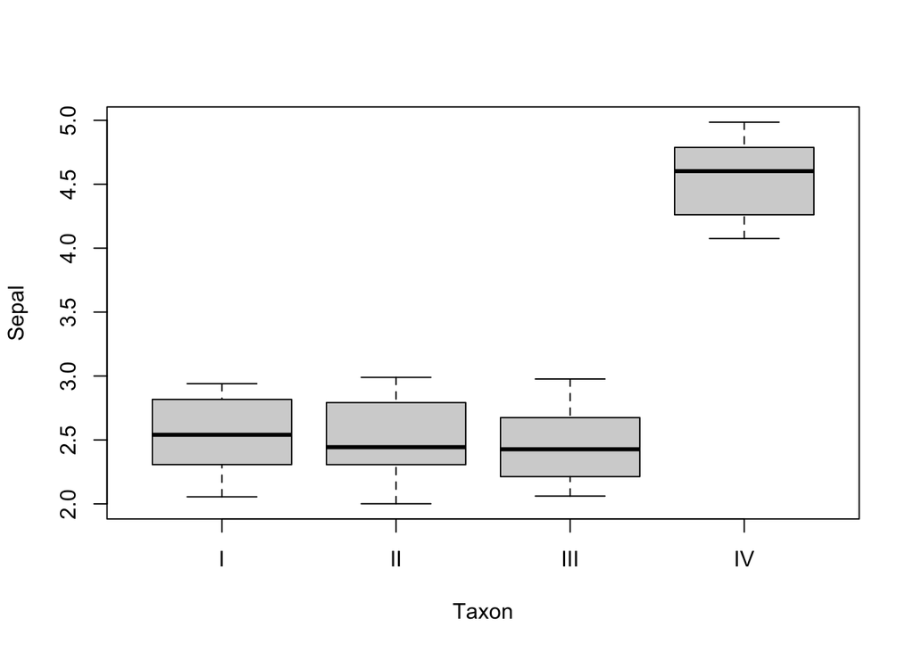

```r
plot(Sepal ~ Taxon, data = taxonomy)
```

We see that taxon 4 has quite different Sepal values than the other taxons, hence Sepal is a good variable to separate taxon 4 from the other 3 taxons.

5. Use similar plots like in d. to identify other variables which are promising with regard to separating taxa I, II and III (Sepal is already a good variable to distinguish taxon IV from the others). Fit an extended model with the variables you have chosen.

**Solution**

I have found two variables which are promising; `Leaf` and `Petiole`, as shown in the figures below.

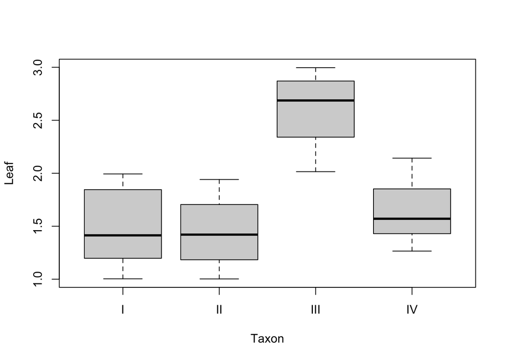

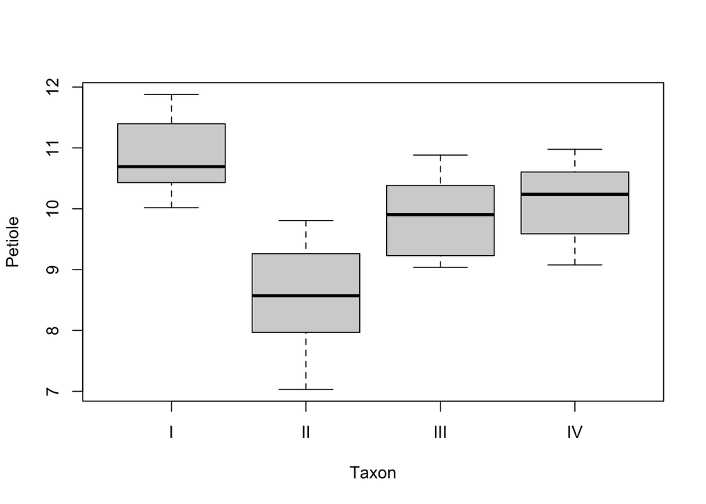

`Leaf` seems to distinguish taxon III from the others, and `Petiole` may separate taxa I and II.

I therefore fit a model with `Sepal`, `Leaf` and `Petiole` as predictors for taxa:

```r
mod2.multi <- multinom(Taxon ~ Sepal + Leaf + Petiole, data=taxonomy, trace=FALSE)
summaryMultinom(mod2.multi)
```

```
## Call:
## multinom(formula = Taxon ~ Sepal + Leaf + Petiole, data = taxonomy,
##     trace = FALSE)
##
## II                  Coef   SE Coef          Z         P
##   (Intercept) 284.646310 386.34516  0.7367669 0.4612641
##   Sepal        15.046821  43.26230  0.3478045 0.7279870
##   Leaf          6.685383  27.11027  0.2465997 0.8052180
##   Petiole     -34.089410  49.90635 -0.6830676 0.4945641
##
## III                Coef   SE Coef           Z         P
##   (Intercept) -33.62852 255.31174 -0.13171552 0.8952093
##   Sepal       -13.10229 156.55190 -0.08369293 0.9333006
##   Leaf        150.08212 114.67467  1.30876429 0.1906142
##   Petiole     -23.85619  25.02644 -0.95323924 0.3404689
##
## IV                  Coef    SE Coef           Z            P
##   (Intercept) -68.326719   9.500774 -7.19170018 6.398942e-13
##   Sepal        40.983380 280.681854  0.14601364 8.839106e-01
##   Leaf          4.716503 261.442945  0.01804028 9.856067e-01
##   Petiole      -6.738204  95.647421 -0.07044836 9.438368e-01
##
## Analysis of Deviance Table (Type II tests)
##
## Response: Taxon
##         LR Chisq Df Pr(>Chisq)
## Sepal    102.810  3  < 2.2e-16 ***
## Leaf      93.007  3  < 2.2e-16 ***
## Petiole   82.133  3  < 2.2e-16 ***
## ---
## Signif. codes:  0 '***' 0.001 '**' 0.01 '*' 0.05 '.' 0.1 ' ' 1
##
## Residual Deviance: 0.2178
## AIC: 24.2178
## 'log Lik.' -0.1089153 (df=12)
```